# practice quiz 2

### Practice Quiz: Доверительные интервалы для долей

```python
import numpy as np
from statsmodels.stats.proportion import proportion_confint
```

### Question 2

Большая часть млекопитающих неспособны во взрослом возрасте переваривать лактозу, содержащуюся в молоке. У людей за расщепление лактозы отвечает фермент лактаза, кодируемый геном LCT. У людей с вариантом 13910T этого гена лактаза продолжает функционировать на протяжении всей жизни. Распределение этого варианта гена сильно варьируется в различных генетических популяциях.

Из 50 исследованных представителей народа майя вариант 13910T был обнаружен у одного. Постройте нормальный 95% доверительный интервал для доли носителей варианта 13910T в популяции майя. Чему равна его нижняя граница? Округлите ответ до 4 знаков после десятичной точки.

```python
n = 50
```

```python
normal_interval = proportion_confint(1, n, alpha=0.05, method='normal')
```

```python
print 'normal_interval [%f, %f] with width %f' % (normal_interval[0],
                                                  normal_interval[1],
                                                  normal_interval[1] - normal_interval[0])
```

```
normal_interval [-0.018805, 0.058805] with width 0.077611
```

### Question 3

В условиях предыдущей задачи постройте 95% доверительный интервал Уилсона для доли носителей варианта 13910T в популяции майя. Чему равна его нижняя граница? Округлите ответ до 4 знаков после десятичной точки.

```python
wilson_interval = proportion_confint(1, n, alpha=0.05, method='wilson')
```

```python
print 'wilson_interval [%f, %f] with width %f' % (wilson_interval[0],
                                                  wilson_interval[1],
                                                  wilson_interval[1] - wilson_interval[0])
```

```
wilson_interval [0.003539, 0.104954] with width 0.101415
```

### Question 4

Какой из двух построенных доверительных интервалов выглядит более вменяемым, учитывая, что параметр, для которого строится оценка, меняется от 0 до 1?

Уилсона

### Qestion 5

Пусть в популяции майя действительно 2% носителей варианта 13910T, как в выборке, которую мы исследовали. Какой объём выборки нужен, чтобы с помощью нормального интервала оценить долю носителей гена 13910T с точностью ±0.01 на уровне доверия 95%?

```python
from statsmodels.stats.proportion import samplesize_confint_proportion
```

```python
n_samples = int(np.ceil(samplesize_confint_proportion(1.0/50, 0.01)))
n_samples
```

```
753
```

### Qestion 6

Постройте график зависимости объёма выборки, необходимого для оценки для доли носителей гена 13910T с точностью ±0.01 на уровне доверия 95%, от неизвестного параметра p. Посмотрите, при каком значении p нужно больше всего испытуемых. Как вы думаете, насколько вероятно, что выборка, которую мы анализируем, взята из случайной величины с этим значением параметра?

Как бы вы не ответили на последний вопрос, рассмотреть объём выборки, необходимый при таком p, всё равно полезно — это даёт максимально пессимистичную оценку необходимого объёма выборки.

Какой объём выборки нужен в худшем случае, чтобы с помощью нормального интервала оценить долю носителей гена 13910T с точностью ±0.01 на уровне доверия 95%?

```python
samples_func = lambda p: int(np.ceil(samplesize_confint_proportion(p, 0.01)))
x = np.arange(0, 1.01, step=0.01)
y = np.array([samples_func(xi) for xi in x])
```

```python
import matplotlib.pyplot as plt
%matplotlib inline
```

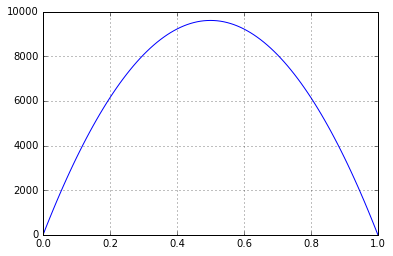

```python
plt.plot(x, y)
plt.grid(True)
plt.show()
```

```python
max_samples = y.max()
max_samples
```

```
9604
```